# Introduction to StatComp21059

(2)由于样本量为10000，根据中心极限定理，令y1=x1/10000,表示simulation得出的method1的power估计值，y2=x2/10000,表示simulation得出的method2的power估计值，则y1服从均值为p1,方差为p1(1-p1)/10000的正态分布,y2服从均值为p2,方差为p2(1-p2)/10000的正态分布,由于y1和y2是运用相同的样本数据得出的，不具有独立性，所以不能仅用一组数据来做假设检验，应当使用paired-t test。

(3)根据(2)的分析，应当进行多次simulation setting with 10000 experiments，从而得出多组y1,y2的成对数据，以此进行paired-t test.

10-21: 1.repeat Example6.8: In our simulation ,we generate variables following $N(\mu,\Sigma)$, where:
$$\mu=(0,0,0)^{T} , \Sigma=\left( \begin{array}{ccc}
1 & 0 & 0 \\
0 & 1 & 0 \\
0 & 0 & 1 \end{array} \right).$$

```r
library(MASS)
#编写一个函数Mardiatest
Mardiatest<-function(data){
  n=nrow(data)
  c=ncol(data)
  x<-data
  for(i in 1:c){
    x[,i]<-data[,i]-mean(data[,i])
  }
  sigmahat<-t(x)%*%x/n
  a<-x%*%solve(sigmahat)%*%t(x)
  b<-sum(colSums(a^3))/(n^2)#计算出检验统计量
  test<-n*b/6
  cv<-qchisq(0.95,c*(c+1)*(c+2)/6)  #调用卡方分布的临界值
  as.integer(test>cv)  #通过取整函数，得到拒绝原假设的个数
}

set.seed(123)
mu <- c(0,0,0)
sigma <- matrix(c(1,0,0,0,1,0,0,0,1),nrow=3,ncol=3)
m=1000
n<-c(10, 20, 30, 50, 100, 500)
#m: 重复次数; n: 样本容量
a=numeric(length(n))
for(i in 1:length(n)){
  a[i]=mean(replicate(m, expr={
    data <- mvrnorm(n[i],mu,sigma) #调用服从多元正态分布的随机数，生成矩阵data
    Mardiatest(data)
  }))
}
print(a)
```

```
## [1] 0.001 0.022 0.044 0.040 0.054 0.038
```

此处计算得出的a就是t1e，基本小于0.05

2.repeat Example 6.10 which evaluate the power of Mardia’s multivariate skewness test under distribution $(1-\epsilon)N(\mu_{1},\Sigma_{1})+\epsilon N(\mu_{2},\Sigma_{2})$, where:
$$\mu_{1}=\mu_{2}=(0,0,0)^{T}, \Sigma_{1}=\left( \begin{array}{ccc}
1 & 0 & 0 \\
0 & 1 & 0 \\
0 & 0 & 1 \end{array} \right)
\Sigma_{2}=\left( \begin{array}{ccc}
100 & 0 & 0 \\
0 & 100 & 0 \\
0 & 0 & 100 \end{array} \right).$$

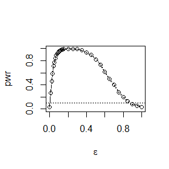

```r
library(MASS)
#把之前定义的函数再复制一遍
Mardiatest<-function(data){
  n=nrow(data)
  c=ncol(data)
  x<-data
  for(i in 1:c){
    x[,i]<-data[,i]-mean(data[,i])
  }
  sigmahat<-t(x)%*%x/n
  a<-x%*%solve(sigmahat)%*%t(x)
  b<-sum(colSums(a^3))/(n^2)
  test<-n*b/6
  cv<-qchisq(0.95,c*(c+1)*(c+2)/6)
  as.integer(test>cv)
}
#输入两个正态分布的参数
mu1 <- mu2 <- c(0,0,0)
sigma1 <- matrix(c(1,0,0,0,1,0,0,0,1),nrow=3,ncol=3)
sigma2 <- matrix(c(100,0,0,0,100,0,0,0,100),nrow=3,ncol=3)
alpha <- .1
n <- 30
m <- 2500
epsilon <- c(seq(0, .15, .01), seq(.15, 1, .05))
N <- length(epsilon)
pwr <- numeric(N)
for (j in 1:N) { #for each epsilon
    e <- epsilon[j]
    sktests <- numeric(m)
    for (i in 1:m) { #每次重复，以概率1-e和e抽取两个正态分布的随机样本
       index=sample(c(1, 2), replace = TRUE, size = n, prob = c(1-e, e))
       data<-matrix(0,nrow=n,ncol=3)
       for(t in 1:n){
          if(index[t]==1)
            data[t,]=mvrnorm(1,mu1,sigma1)
          else
            data[t,]=mvrnorm(1,mu2,sigma2)
       }
       sktests[i] <- Mardiatest(data)
    }
    pwr[j] <- mean(sktests)
}
#plot power vs epsilon
plot(epsilon, pwr, type = "b",xlab = bquote(epsilon), ylim = c(0,1))
abline(h = .1, lty = 3)
se <- sqrt(pwr * (1-pwr) / m) #add standard errors
lines(epsilon, pwr+se, lty = 3)
lines(epsilon, pwr-se, lty = 3)
```

10-28: 7.7:

```r
library(bootstrap)
set.seed(123)
n<-nrow(scor)
lambda_hat<-eigen(cov(scor))$val
theta_hat<-lambda_hat[order(lambda_hat,decreasing=TRUE)[1]]/sum(lambda_hat)
B<-1e2
thetastar<-numeric(B)
for (b in 1:B) {
  i <- sample(1:n, size = n, replace = TRUE)
  data<-scor[i,]
  lambda<-eigen(cov(data))$val
  thetastar[b]<-lambda[order(lambda,decreasing=TRUE)[1]]/sum(lambda)
}
se<- sd(thetastar)
bias<- mean(thetastar - theta_hat)
round(c(se,bias),4)
```

```
## [1] 0.0438 0.0019
```

7.8

```r
library(bootstrap)
set.seed(123)
n = nrow(scor)
lambda_hat = eigen(cov(scor))$val
theta_hat = lambda_hat[order(lambda_hat,decreasing=TRUE)[1]]/sum(lambda_hat)
theta_j = rep(0,n)
for (i in 1:n) {
    x = scor [-i,]
    lambda = eigen(cov(x))$val
    theta_j[i] = lambda[order(lambda,decreasing=TRUE)[1]]/sum(lambda)
}
#estimated bias of theta_hat
bias_jack = (n-1)*(mean(theta_j)-theta_hat)
#estimated se of theta_hat
se_jack = (n-1)*sqrt(var(theta_j)/n)
print(round(c(bias_jack=bias_jack,se_jack=se_jack),4))
```

```
## bias_jack   se_jack
##    0.0011    0.0496
```

7.9:

```r
library(boot)
library(bootstrap)
data(scor, package = "bootstrap")
theta.boot<-function(x,i){
  data<-scor[i,]
  lambda<-eigen(cov(data))$val
  theta.b<-lambda[order(lambda,decreasing=TRUE)[1]]/sum(lambda)
}
boot.obj <- boot(scor, statistic = theta.boot, R = 2000)
alpha <- c(.025, .975)
print(quantile(boot.obj$t, alpha, type=6))
```

```
##      2.5%     97.5%
## 0.5282721 0.7082614
```

7.B:

```r
skewness <- function(x){
  xbar <- mean(x)
  m1 <- mean((x-xbar)^3)
  m2 <- mean((x-xbar)^2)
  return( m1 / m2^1.5 )
}
library(boot)
mu <- 0  # the skewness of normal distribution
n <- 20  # the sample size
m <- 1e2 # replicate time

boot.skew <- function(x,i) {
  skewness(x[i])
}

ci.norm <- ci.basic <- ci.perc <- matrix(NA,m,2)
for(i in 1:m){
  X <- rnorm(n)
  de <- boot(data = X, statistic = boot.skew, R = 1e3)
  ci <- boot.ci(de,type = c("norm","basic","perc"))
  ci.norm[i,] <- ci$norm[2:3]
  ci.basic[i,] <- ci$basic[4:5]
  ci.perc[i,] <- ci$percent[4:5]
}

cover.prob <- c(mean(ci.norm[,1]<= mu & ci.norm[,2]>= mu),
                mean(ci.basic[,1]<= mu & ci.basic[,2]>= mu),
                mean(ci.perc[,1]<= mu & ci.perc[,2]>= mu))

left.omit <- c(mean(ci.norm[,1]>= mu),
               mean(ci.basic[,1]>= mu),
               mean(ci.perc[,1]>= mu))

right.omit <- c(mean(ci.norm[,2]<= mu),
               mean(ci.basic[,2]<= mu),
               mean(ci.perc[,2]<= mu))
cover.norm <- matrix(data = c(cover.prob,left.omit,right.omit),nrow = 3,byrow = TRUE,)
rownames(cover.norm) <- c("cover probability","miss on the left","miss on the right")
colnames(cover.norm) <- c("standard normal bootstrap confidence interval","basic bootstrap confidence interval","percentile bootstrap confidence interval")
print(cover.norm)
```

```
##                   standard normal bootstrap confidence interval
## cover probability                                          0.88
## miss on the left                                           0.06
## miss on the right                                          0.06
##                   basic bootstrap confidence interval
## cover probability                                0.84
## miss on the left                                 0.08
## miss on the right                                0.08
##                   percentile bootstrap confidence interval
## cover probability                                     0.97
## miss on the left                                      0.02
## miss on the right                                     0.01
```

```r
library(boot)
mu <- sqrt(8/5)  # the skewness of chi-squared distribution
n <- 20  # the sample size in bootstrap
m <- 1e3 # replicate time in Monte Carlo experiments


ci.norm <- ci.basic <- ci.perc <- matrix(NA,m,2)

for(i in 1:m){
  X <- rchisq(n,df = 5)
  de <- boot(data = X, statistic = boot.skew, R = 1e3)
  ci <- boot.ci(de,type = c("norm","basic","perc"))
  ci.norm[i,] <- ci$norm[2:3]
  ci.basic[i,] <- ci$basic[4:5]
  ci.perc[i,] <- ci$percent[4:5]
}


cover.prob <- c(mean(ci.norm[,1]<= mu & ci.norm[,2]>= mu),
                mean(ci.basic[,1]<= mu & ci.basic[,2]>= mu),
                mean(ci.perc[,1]<= mu & ci.perc[,2]>= mu))
left.omit <- c(mean(ci.norm[,1]>= mu),
               mean(ci.basic[,1]>= mu),
               mean(ci.perc[,1]>= mu))
right.omit <- c(mean(ci.norm[,2]<= mu),
               mean(ci.basic[,2]<= mu),
               mean(ci.perc[,2]<= mu))

cover.chisq <- matrix(data = c(cover.prob,left.omit,right.omit),nrow = 3,byrow = TRUE,)
rownames(cover.chisq) <- c("cover probability","miss on the left","miss on the right")
colnames(cover.chisq) <- c("standard normal bootstrap confidence interval","basic bootstrap confidence interval","percentile bootstrap confidence interval")
print(cover.chisq)
```

```
##                   standard normal bootstrap confidence interval
## cover probability                                         0.722
## miss on the left                                          0.020
## miss on the right                                         0.258
##                   basic bootstrap confidence interval
## cover probability                               0.699
## miss on the left                                0.030
## miss on the right                               0.271
##                   percentile bootstrap confidence interval
## cover probability                                    0.711
## miss on the left                                     0.000
## miss on the right                                    0.289
```

11-04: 8.2:

```r
x <- c(60, 68, 68, 77, 74, 77, 80)
y <- c(61, 67, 69, 76, 74, 80, 68)
m<-1e3
u <- c(x,y)
zt <- function(x,y){
  n <- length(x)
  x <- rank(x, ties.method = "average")
  y <- rank(y, ties.method = "average")
  v<-n * ((n+1)/2)^2
  for (i in 1:n) {
    r1 = sum(x[i] * y[i]) - v
    r2 = sum(x[i]^2) -v
    r3 = sum(y[i]^2) - v
  }
  r1/sqrt(r2 * r3)
}
zt_initial <- zt(x,y)
t <- t1 <- t2 <- r_permutation <- numeric(m)
for (i in 1:m) {
  t <- sample(u, size = 14,replace = FALSE)
  t1 <- t[1:7]
  t2 <- t[8:14]
  r_permutation[i] <- zt(t1,t2)
}
p_permutation <- mean(r_permutation < zt_initial)
print(p_permutation)
```

```
## [1] 0.099
```

11-11: 9.3：

```
set.seed(123)
m<-2000
x<-numeric(m)
x[1]<-rt(1,1)
k<-0
u<-runif(m)
for (i in 2:m){
  xt<-x[i-1]
  y<-rt(1,abs(xt))
  zt1<-dt(xt,abs(y))*{1/pi*(1+y^2)}
  zt2<-dt(y,abs(xt))*{1/pi*(1+xt^2)}
  if (zt1==0){
    c<-0
  }
  else {
    c<-zt1/zt2
  }
  if (u[i]<=c)
    x[i]<-y
  else{
    x[i]<-xt
    k<-k+1
  }
}
index<-1:1000
y1<-x[index]
y<-x[1001:m]
a<-seq(0.1,0.9,0.1)
QR<-qcauchy(a)
Q<-quantile(y,a)
qqplot(QR,Q,main="",xlab="Cauchy Quantiles",ylab="Sample Quantiles")
```

9.8:

```
N<-5000
burn<-1000
X<-matrix(0,N,2)
X[1,]<-c(0,0)
a<-5
b<-10
n<-15
for (i in 2:N) {
  x2<-X[i-1,2]
  X[i,1]<-rbinom(1,n,x2)
  x1<-X[i,1]
  X[i,2]<-rbeta(1,x1+a,n-x1+b)
}
d<-burn+1
x<-X[d:N,]
plot(X)
```

9.3附加：

[output not shown]

9.8附加

```r
Gelman.Rubin<-function(zt){
  zt<-as.matrix(zt)
  n<-ncol(zt)
  k<-nrow(zt)
  zt_means<-rowMeans(zt)
  B<-n*var(zt_means)
  zt_w<-apply(zt,1,"var")
  W<-mean(zt_w)
  v.hat<-W*(n-1)/n+(B/n)
  r.hat<-v.hat/W
  return(r.hat)
}
```

11-18: 11.3：

```r
a_Euc<-function(a){#定义欧式距离
  norm(a,type="F")
}
k_th<-function(a,k){#计算第k项
  d<-length(a)
  (-1)^k/(factorial(k)*2^k)*a_Euc(a)^(2*k+2)/((2*k+1)*(2*k+2))*exp(lgamma((d+1)/2)+lgamma(k+3/2)-lgamma(k+d/2+1))
}
zt<-function(a){
  s<-0
  k<-0
  g<-1
  while(abs(g)>1e-10){##当第k项绝对值小于1e-10时认为级数收敛
    s<-s+k_th(a,k)
    k<-k+1
    g<-k_th(a,k)
  }
  return(s)
}
a<-matrix(c(1,2),2,1)
zt(a)#计算a=（1，2）时的和
```

```
## [1] 1.532164
```

11.5:

```r
k<-4
C_k<-function(k,a){
  (a^2*k/(k+1-a^2))^0.5
}
gyj<-function(a,k){
  pt(C_k(k,a),k)
}
zt<-uniroot(function(x) {gyj(x,k)-gyj(x,k-1)},lower=1,upper=2)
zt$root
```

```
## [1] 1.492103
```

3:

```r
y<-c(0.54,0.48,0.33,0.43,0.91,0.21,0.85)
n<-10
m<-3
lambda<-1
zt<-function(y,lambda,x){
  y_sum<-sum(y)
  E<-n*log(x)-x*y_sum-x*m*exp(-lambda)
  return(-E)
}
lambda<-optim(lambda,function(x){zt(y,lambda,x)},method="BFGS")
```

11-25: page204: 1: Since the essence of the lapply function is to iterate through each element of a list vector and process its elements using the specified function, the lapply function returns the list vector. For lapply(trims,function(trim) mean(x,trim=trim)), it means that for the given vector trims<-c(0,0.1,0.2,0.5), take each element as the parameter trim to be pruned in mean function, For example, when trimS is 0.1, it means that the maximum and minimum 100*0.1=10 digits are deleted and then the average value is taken. For Lapply (trims,mean,x=x), elements in the given vector TRIMs are directly taken as parameters in mean function, and x is taken as other parameters in Lapply. Therefore, there is no need to define function in addition, and the results obtained are the same.

page 204: 5:

```r
rsq <- function(mod) summary(mod)$r.squared
formulas <- list(
  mpg ~ disp,
  mpg ~ I(1 / disp),
  mpg ~ disp + wt,
  mpg ~ I(1 / disp) + wt
)
zt1<-lapply(formulas, lm,data=mtcars)
zt2<-lapply(zt1,rsq)
print(zt2)
```

```
## [[1]]
## [1] 0.7183433
##
## [[2]]
## [1] 0.8596865
##
## [[3]]
## [1] 0.7809306
##
## [[4]]
## [1] 0.8838038
```

page 214: 1(a):

```r
x<-data.frame(cbind(x1=seq(2,8,2),x2=c(1:4)))
zt<-vapply(x, sd, FUN.VALUE = c('a'=0))
print(zt)
```

```
##       x1       x2
## 2.581989 1.290994
```

```r
#结果显示第一列向量（2，4，6，8）的标准差为2.581989，第二列向量（1，2，3，4）的标准差为1.290994
```

(b):

```r
x<-data.frame(a=1:5,b=runif(5),c=c(TRUE,FALSE,TRUE,FALSE,TRUE))
zt1<-vapply(x, is.numeric, logical(1))
zt2<-vapply(x[zt1], sd, FUN.VALUE = c('a'=0))
print(zt2)
```

```
##         a         b
## 1.5811388 0.1439638
```

page 214:7:

```
function (cl = NULL, X, fun, ..., chunk.size = NULL)
{
    cl <- defaultCluster(cl)
    nchunks <- staticNChunks(length(X), length(cl), chunk.size)
    do.call(c, clusterApply(cl = cl, x = splitList(X, nchunks),
        fun = sapply, FUN = fun, ...), quote = TRUE)
}
```

12-02:

```
library(Rcpp)
library(microbenchmark)
dir_cpp <- 'C:/Users/支彤/Desktop/统计计算/'
sourceCpp(paste0(dir_cpp,"gibbsC.cpp"))
source(paste0(dir_cpp,"gibbsR.R"))
set.seed(1230)
gibbR<-gibbsR(100,10)
gibbC<-gibbsC(100,10)
qqplot(gibbR,gibbC)
ts <- microbenchmark(gibbC=gibbsC(100,10),gibbR=gibbsR(100,10))
summary(ts)[,c(1,3,5,6)]
```

```
#用Rcpp function实现Exercise9.8
set.seed(1115)
cppFunction('NumericMatrix gibbsC(int N, int n,int a,int b) {
  NumericMatrix mat(N, 2);
  double x = 0, y = 0;
  for(int i = 1; i < N; i++) {
    y=mat(i-1,1);
    mat(i,0)=rbinom(1, n, y)[0];
    x=mat(i,0);
    mat(i,1)=rbeta(1, x+a, n-x+b)[0];
  }
  return(mat);
}')
#用r语言实现
gibbsR <- function(N, n, a, b) {
  mat <- matrix(nrow = N, ncol = 2)
  mat[1,]<-c(0,0)
  for (i in 2:N) {
    y<-mat[i-1,2]
    mat[i,1]<-rbinom(1,n,y)
    x<-mat[i,1]
    mat[i,2]<-rbeta(1,x+a,n-x+b)
  }
  mat
}
```